# Monitoring Effects and Monitoring Rates 2013 - 2021

2023-04-10

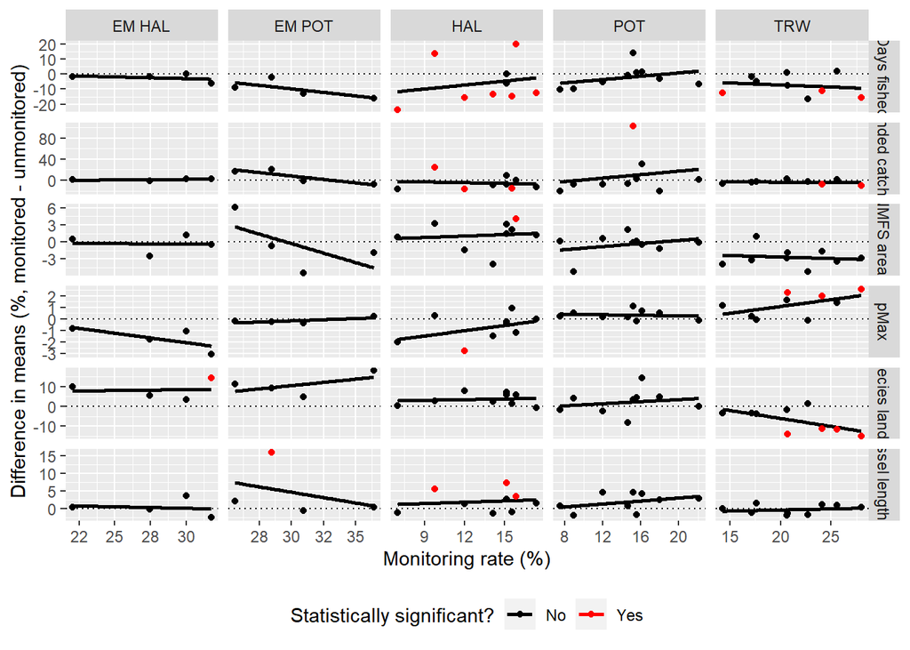

Figure 1. Difference in means (%, monitored - unmonitored) against monitoring rate for years 2013 through 2021. Each point represents one year of data. Lines represent the linear regression of the points. We labeled points statistically significant if the *p*-value from the permutation test was $\le$ 0.05/6 for that year of data. We labeled lines statistically significant if the *p*-value for the linear model slope coefficient was $\le$ 0.05/6.

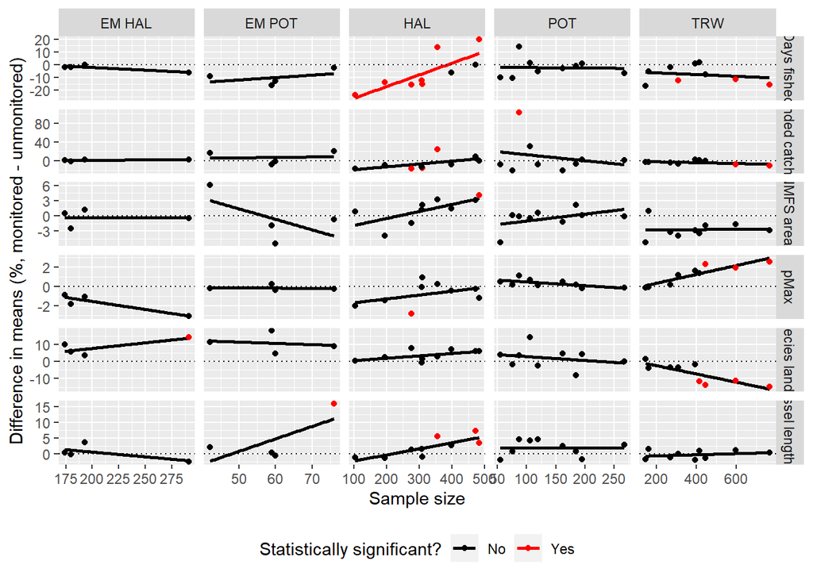

Figure 2. Difference in means (%, monitored - unmonitored) against sample size for years 2013 through 2021. Each point represents one year of data. Lines represent the linear regression of the points. We labeled points statistically significant if the *p*-value from the permutation test was $\le$ 0.05/6 for that year of data. We labeled lines statistically significant if the *p*-value for the linear model slope coefficient was $\le$ 0.05/6.

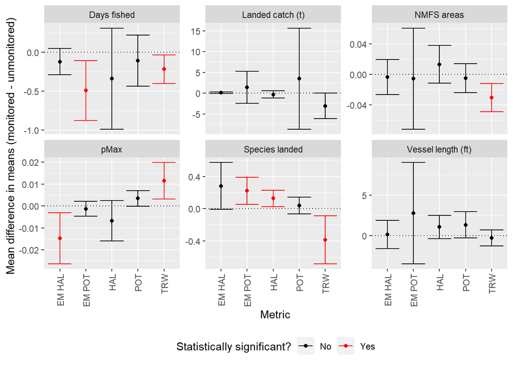

Figure 3. Mean difference in means (monitored - unmonitored) across all years of data from 2013 through 2021. Error bars represent 95% confidence intervals. We labelled results statistically significant if the 95% confidence interval does not contain 0.